# Problem Set 1

Author

Yinjiao Zhong

Published

April 12, 2024

```r
library(car)
library(carData)
library(tidyverse)
```

# 1 Question 1

```r
data1 <- read.csv("data_q1.csv")
head(data1)
```

```
   group   scores
1 group1 91.23661
2 group1 92.45948
3 group1 81.99049
4 group1 92.86250
5 group1 81.48261
6 group1 82.78499
```

## 1.1 a

**Answer**:

- **$H_0$ (Null hypothesis):** There is no significant different in quiz scores across the three study groups.
- **$H_A$ (Alternative hypothesis):** There is a significant difference in quiz score across the three study groups.

## 1.2 b

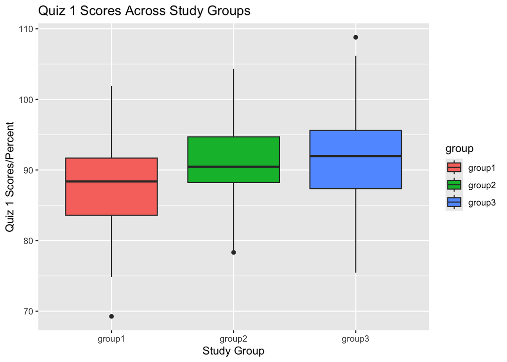

```r
library(ggplot2)
# create a boxplot
plot1 <- ggplot(data1, aes(x = group, y = scores, fill = group))
boxplot <- plot1 + geom_boxplot()
label_plot <- boxplot + labs(title = "Quiz 1 Scores Across Study Groups", x = "Study Group", y = "Quiz 1 Scores/Percent")
print(label_plot)
```

**Answer**:

From the box plot, the mean score of group 1 seem lower than that of the other two groups.

## 1.3 c

**Answer**:

Since we have a categorical independent variable (study group) and a continuous dependent variable (quiz score), we can use one-way ANOVA tests. Before performing ANOVA tests, we need to check whether the assumption is that quiz scores in each group are approximately normally distributed and that the variance of quiz scores across all groups should be approximately equal.

```r
# check normality assumption
group1 <- filter(data1, group=='group1')
group2 <- filter(data1, group=='group2')
group3 <- filter(data1, group=='group3')

dim(group1)
```

```
[1] 100   2
```

```r
dim(group2)
```

```
[1] 100   2
```

```r
dim(group3)
```

```
[1] 100   2
```

```r
shapiro.test(group1$scores)
```

```
    Shapiro-Wilk normality test

data:  group1$scores
W = 0.99294, p-value = 0.8845
```

```r
shapiro.test(group2$scores)
```

```
    Shapiro-Wilk normality test

data:  group2$scores
W = 0.99045, p-value = 0.7011
```

```r
shapiro.test(group3$scores)
```

```
    Shapiro-Wilk normality test

data:  group3$scores
W = 0.99378, p-value = 0.9302
```

```r
# check homogeneity of variances assumption
#group <- as.factor(group)
leveneTest(scores ~ group, data = data1, center = mean)
```

```
Levene's Test for Homogeneity of Variance (center = mean)
       Df F value Pr(>F)
group   2  1.3344 0.2649
      297
```

**Conclusion**:

As the reasult, in the leveneTest the P-value is 0.2649 > alpha = 0.05, we can not reject the null hypothesis, so the variance is equal among the groups. From the shapiro test of each group, all the P-value > alpha = 0.05, we can not reject the null hypothesis, so scores are normally distributed.

## 1.4 d

```r
# use ANOVA test
anova <- aov(scores ~ group, data = data1)
summary(anova)
```

```
             Df Sum Sq Mean Sq F value   Pr(>F)
group         2    876   438.2   12.26 7.65e-06 ***
Residuals   297  10614    35.7
---
Signif. codes:  0 '***' 0.001 '**' 0.01 '*' 0.05 '.' 0.1 ' ' 1
```

```r
# use post-hoc test
TukeyHSD(anova)
```

```
  Tukey multiple comparisons of means
    95% family-wise confidence level

Fit: aov(formula = scores ~ group, data = data1)

$group
                  diff        lwr      upr     p adj
group2-group1 2.993588  1.0021667 4.985008 0.0013410
group3-group1 4.031379  2.0399580 6.022800 0.0000087
group3-group2 1.037791 -0.9536295 3.029212 0.4378540
```

**Answer**:

**-** Because the P-value of ANOVA test is 7.65e-06<< alpha = 0.05, we can reject the null hypothesis that there are significant differences in quiz scores between the experimental groups. So I chose Tukey’s HSD for a post hoc test to determine which groups were significantly different from each other.

**-** The results showed that the p adj = 0.001341 and 0.0000087 < alpha = 0.05 between group1 and group2 and group3 was significant, but the p adj = 0.437854 > alpha=0.05 between group2 and group3 was not significant.

# 2 Question 2

```r
data2 = read.csv("data_q2.csv")
head(data2)
```

```
     State BirdNum
1 Michigan      38
2 Michigan      50
3 Michigan      37
4 Michigan      36
5 Michigan      64
6 Michigan      54
```

## 2.1 a

**Answer**:

- **$H_0$ (Null hypothesis):** There is no significant different in the mean number of birds between forests in Michigan and Indiana.
- **$H_A$ (Alternative hypothesis):** There is a significant difference in the mean number of birds between forests in Michigan and Indiana.

## 2.2 b

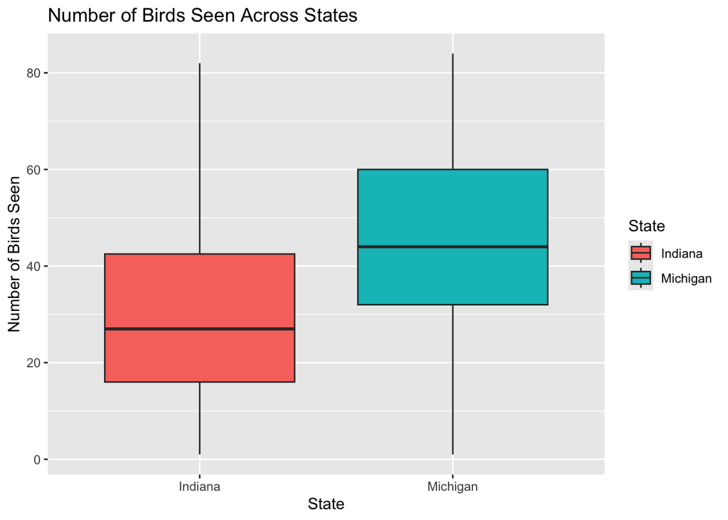

```r
library(ggplot2)
# create a boxplot
plot2 <- ggplot(data2, aes(x = State, y = BirdNum, fill = State))
boxplot <- plot2 + geom_boxplot()
label_plot <- boxplot + labs(title  = "Number of Birds Seen Across States", x = "State", y = "Number of Birds Seen")
print(label_plot)
```

From this box plot, there is different in the mean number of birds between forests in Michigan and Indiana.

## 2.3 c

**Answer**:

**-** Since we are comparing the mean of a continuous variable (BirdNum) between two independent populations (Michigan and Indiana), we can use the independent sample T-test. The Shapiro-Wilk normality test was used to assess whether the data within each group were approximately normal distribution.

**-** The results show that the p values of both groups are less than 0.05, which indicates that the normal hypothesis is violated. However, we have large sample size, which is bigger than 30, so this assumption is still satisfied. The homogeneity test of variance showed that the p value was 0.417 and greater than 0.05. The hypothesis of variance homogeneity is satisfied.

```r
# Check normality assumption
MI <- filter(data2, State=='Michigan')
IN <- filter(data2, State=='Indiana')
dim(MI)
```

```
[1] 199   2
```

```r
shapiro.test(data2$BirdNum[data2$State == "Michigan"])
```

```
    Shapiro-Wilk normality test

data:  data2$BirdNum[data2$State == "Michigan"]
W = 0.98364, p-value = 0.02053
```

```r
dim(IN)
```

```
[1] 179   2
```

```r
shapiro.test(data2$BirdNum[data2$State == "Indiana"])
```

```
    Shapiro-Wilk normality test

data:  data2$BirdNum[data2$State == "Indiana"]
W = 0.95828, p-value = 3.706e-05
```

```r
# Check homogeneity of variances assumption

var(data2$BirdNum[data2$State == "Michigan"])
```

```
[1] 400.5883
```

```r
var(data2$BirdNum[data2$State == "Indiana"])
```

```
[1] 355.5547
```

```r
var.test(data2$BirdNum[data2$State == "Michigan"], data2$BirdNum[data2$State == "Indiana"])
```

```
    F test to compare two variances

data:  data2$BirdNum[data2$State == "Michigan"] and data2$BirdNum[data2$State == "Indiana"]
F = 1.1267, num df = 198, denom df = 178, p-value = 0.417
alternative hypothesis: true ratio of variances is not equal to 1
95 percent confidence interval:
 0.8444875 1.4997734
sample estimates:
ratio of variances
          1.126657
```

## 2.4 d

```r
# Run welch two-sample t-test
t.test(MI$BirdNum, IN$BirdNum)
```

```
    Welch Two Sample t-test

data:  MI$BirdNum and IN$BirdNum
t = 7.4323, df = 375.19, p-value = 7.288e-13
alternative hypothesis: true difference in means is not equal to 0
95 percent confidence interval:
 10.93119 18.79577
sample estimates:
mean of x mean of y
 45.37186  30.50838
```

**Answer**:

I used the Welch two-sample T-test to compare average bird populations in two states. The P-value= 7.288e-13 << alpha = 0.05. This shows that we can reject the null hypothesis and conclude that the average number of birds in the two states is significantly different.

# 3 Question 3

```r
data3 <- read.csv("data_q3.csv")
head(data3)
```

```
  Temperature   Chirps
1    21.40962 89.88935
2    15.76820 73.21143
3    21.24025 94.76065
4    18.02732 86.46968
5    19.23554 81.80422
6    16.31509 73.97409
```

## 3.1 a

```r
# Calculate correlation
cor(data3)
```

```
            Temperature    Chirps
Temperature   1.0000000 0.7804302
Chirps        0.7804302 1.0000000
```

**Answer**:

The correlation coefficient between temperature and number of cricket chirps is 0.7804302, this is mean that there is a strong correlation between them, with the number of crickets chirping tending to increase as temperature increased.

## 3.2 b

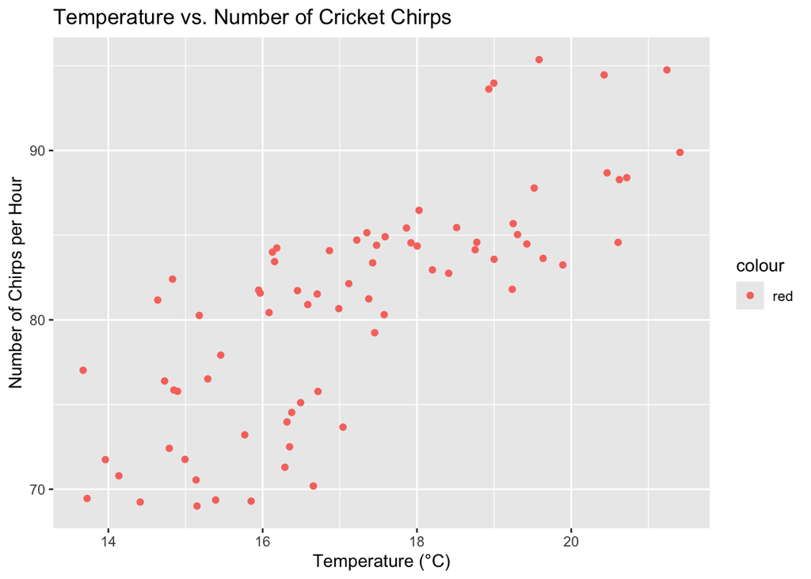

```r
library(ggplot2)
# create a scatter plot
ggplot(data3, aes(x = Temperature, y = Chirps, col = "red")) + geom_point() + labs(title = "Temperature vs. Number of Cricket Chirps", x = "Temperature (°C)", y = "Number of Chirps per Hour")
```

## 3.3 c

**Answer**:

- **$H_0$ (Null hypothesis):** There is no significant association between temperature and the average number of cricket chirps heard per hour.
- **$H_A$ (Alternative hypothesis):** There is a significant association between temperature and the average number of cricket chirps heard per hour.

## 3.4 d

```r
# check homogeneity of variances
# Run linear regression model
lr <- lm(Chirps ~ Temperature, data = data3)
# get residual normality
shapiro.test(residuals(lr))
```

```
    Shapiro-Wilk normality test

data:  residuals(lr)
W = 0.98665, p-value = 0.62
```

```r
# check homoscedasticity
ncvTest(lr)
```

```
Non-constant Variance Score Test
Variance formula: ~ fitted.values
Chisquare = 0.717252, Df = 1, p = 0.39705
```

**Answer**:

**-** I used the scatter plot to check the linear relationship between the independent variable (temperature) and the dependent variable (chirps).

**-** According to the the shapiro.test, the p value is 0.62 > alpha = 0.05, we can not to reject the null hypothesis, he assumption of residual normality is satisfied.

**-** Then I used ncvTest to check the homoscedasticity, because the P-value is 0.39705 > alpha = 0.05, we can not to reject null hypothesis, so the assumption of homoscedasticity is satisfied.

**-** The results all met the assumptions of using linear regression analysis.

## 3.5 e

```r
summary(lr)
```

```
Call:
lm(formula = Chirps ~ Temperature, data = data3)

Residuals:
    Min      1Q  Median      3Q     Max
-9.2856 -2.8206 -0.1462  2.8785  8.2719

Coefficients:
            Estimate Std. Error t value Pr(>|t|)
(Intercept)  35.1067     4.3184    8.13 8.04e-12 ***
Temperature   2.6636     0.2498   10.66  < 2e-16 ***
---
Signif. codes:  0 '***' 0.001 '**' 0.01 '*' 0.05 '.' 0.1 ' ' 1

Residual standard error: 4.22 on 73 degrees of freedom
Multiple R-squared:  0.6091,    Adjusted R-squared:  0.6037
F-statistic: 113.7 on 1 and 73 DF,  p-value: < 2.2e-16
```

**Answer**:

**-**According to the results, the regression coefficient of temperature is 2.6636, and the p value is 2e-16 << alpha = 0.05, indicating that there is a significant positive correlation between temperature and chirps. In other words, as temperatures rise, so does the average number of chirps heard per hour.

**-**The multiple R-squared of the model is 0.6091, which means that the temperature in the model explains 60.91% of the variation in the dependent variable (the average number of chirps heard per hour), indicating that temperature plays an important role in explaining the change in the average number of chirps heard per hour.

**-** The intercept is 35.1067. This means that when Temperature is zero, Chirps is predicted to be 35.1067. The p value is 8.04e-12 << alpha = 0.05, meaning the Chirps is significantly different from zero when Temperature is zero.

**-** From the above, we can conclude that there is a significant positive correlation between temperature and the average number of chirps heard per hour. As the temperature rises, so does the average number of chirps heard per hour.

## 3.6 f

**Answer**:

In this model, the multiple R squared is 0.6091, meaning that the independent variable temperature explains 60.91% of the variation in the dependent variable (the average number of chirps heard per hour). Therefore, the model accounts for some degree of variability. In this model, the residual standard error is 4.22, which is relatively large, indicating that the prediction accuracy of the model may not be high enough. Therefore, I think this model to be of average fit.

# 4 Question 4

```r
data4=read.csv('data_q4.csv')
head(data4)
```

```
     social pet
1 extrovert dog
2 extrovert dog
3 extrovert dog
4 extrovert dog
5 extrovert dog
6 extrovert dog
```

## 4.1 a

**Answer**:

- **$H_0$ (Null hypothesis):** There is no significant association between someone’s social disposition and the type of pet they own.
- **$H_A$ (Alternative hypothesis):** There is a significant association between someone’s social disposition and the type of pet they own.

## 4.2 b

```r
# Run chi-squared test
chi_squared_test <- chisq.test(table(data4$social, data4$pet))

# Print the result
chi_squared_test
```

```
    Pearson's Chi-squared test

data:  table(data4$social, data4$pet)
X-squared = 26.19, df = 2, p-value = 2.055e-06
```

## 4.3 c

**Answer**:

With a P-value is 2.055e-06 less than the significance level (0.05), we can reject the null hypothesis and conclude that there is a significant association between someone’s social disposition and pet type the own.